```python
# Useful starting lines
%matplotlib inline
import numpy as np
import matplotlib.pyplot as plt
%load_ext autoreload
%autoreload 2
```

# Load the data

```python
import datetime
from helpers import *

height, weight, gender = load_data(sub_sample=False, add_outlier=False)
x, mean_x, std_x = standardize(height)
y, tx = build_model_data(x, weight)
```

```python
y.shape, tx.shape
```

```
((10000,), (10000, 2))
```

- Each column of $\tilde{X}$ represents a feature (input variable) of the model. In this case there is an offset so the first column is full of 1, additionally, there is a single feature aka. the height of the individual.
- Each row of the same matrix represents a data point, in this case, the $n$-th individual's coordinate pair (height, weight)=$(x_{n1},y_n)$.
- According to this, if we had the height and weight for 3 individuals, we would have that $$\tilde{X} \in \mathbb{M}_{3\times2}(\mathbb{R})$$ $$\vec{y} \in \mathbb{R}^3.$$ In general, we can say that given $N$ data samples (individuals) and $D$ features, the case of such a regression (with constant offset, will imply $$\tilde{X} \in \mathbb{M}_{N\times(D+1)}(\mathbb{R})$$ $$\vec{y} \in \mathbb{R}^D.$$ The element $\tilde{X}_{N_0, D_0}$ will be the $D_0$'th feature of the $N_0$'th individual. Element $\tilde{X}_{3, 2}$ is then the height of the 3rd individual.
- Sizes do make sense since we have 1e4 individuals or data samples and just one feature.

We define $$\vec{e} = \vec{y} - \tilde{X}\vec{w}$$ The loss is defined as $$\mathcal{L}(\vec{w}) = \frac{1}{2N}\sum_n^N(y_n - \tilde{X}_{nj}w_j)^2$$ and sum over repeated indices is implied. This clearly accounts for $$\mathcal{L}(\vec{w}) = \frac{1}{2N}\sum_n^N(e_n)^2$$ $$\mathcal{L}(\vec{w}) = \frac{1}{2N}\vec{e}\cdot\vec{e}$$ $$\mathcal{L}(\vec{w}) = \frac{1}{2N}|\vec{e}(\vec{w})|^2$$

# 1 Computing the Cost Function

Fill in the `compute_loss` function below:

```python
#Helpers from old solutions to compare implementations
def calculate_mse(e):
    """Calculate the mse for vector e."""
    return 1/2*np.mean(e**2)


def calculate_mae(e):
    """Calculate the mae for vector e."""
    return np.mean(np.abs(e))
```

```python
def compute_loss(y, tx, w, kind = 'mse'):
    """Calculate the loss.
    You can calculate the loss using mse or mae.
    """
    error = y - tx.dot(w)
    if kind == 'mse':
        return error.dot(error)/(2*len(y))
    elif kind == 'mae':
        return sum(abs(error))/(2*len(y))
    else:
        raise NotImplementedError
print(compute_loss(y, tx, [1,2], kind = 'mae'))
print(compute_loss(y, tx, [1,2], kind = 'mse'))
```

```
36.14696100105258
2694.4833658870843
```

# 2 Grid Search

Fill in the function `grid_search()` below:

```python
def grid_search(y, tx, w0, w1, kind = 'mse'):
    """Algorithm for grid search."""
    losses = np.zeros((len(w0), len(w1)))
    for i,w0_ in enumerate(w0):
        for j,w1_ in enumerate(w1):
            losses[i,j] = compute_loss(y, tx, [w0_, w1_], kind=kind)
    return losses
```

Let us play with the grid search demo now!

## Test with MSE and grid spacing 10

```
Grid Search: loss*=42.424483146782485, w0*=66.66666666666669, w1*=16.666666666666686, execution time=0.005 seconds
```

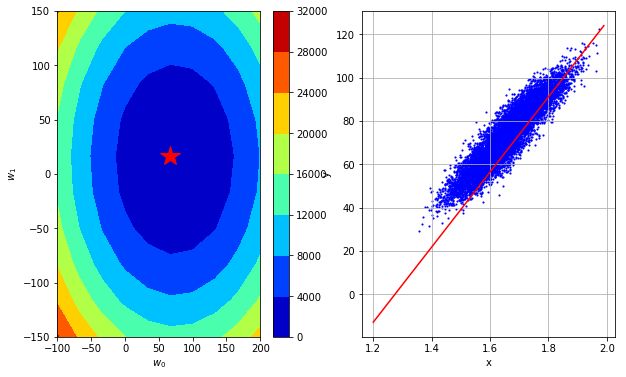

```python
from grid_search import generate_w, get_best_parameters
from plots import grid_visualization

# Generate the grid of parameters to be swept
grid_w0, grid_w1 = generate_w(num_intervals=10)

# Start the grid search
start_time = datetime.datetime.now()
grid_losses = grid_search(y, tx, grid_w0, grid_w1)

# Select the best combinaison
loss_star, w0_star, w1_star = get_best_parameters(grid_w0, grid_w1,
                                                  grid_losses)
end_time = datetime.datetime.now()
execution_time = (end_time - start_time).total_seconds()

# Print the results
print(
    "Grid Search: loss*={l}, w0*={w0}, w1*={w1}, execution time={t:.3f} seconds"
    .format(l=loss_star, w0=w0_star, w1=w1_star, t=execution_time))

# Plot the results
fig = grid_visualization(grid_losses, grid_w0, grid_w1, mean_x, std_x, height,
                         weight)
fig.set_size_inches(10.0, 6.0)
fig.savefig("grid_plot")  # Optional saving
```

## Test with MSE and grid spacing 50

```
Grid Search: loss*=18.79354101952324, w0*=71.42857142857142, w1*=15.306122448979579, execution time=0.115 seconds
```

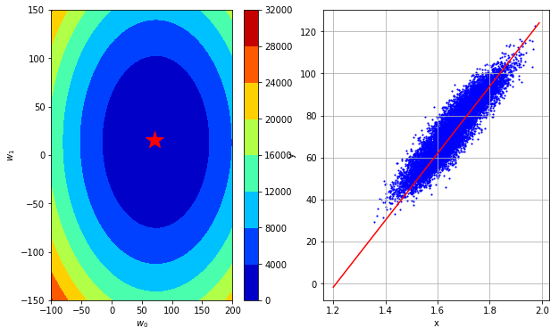

```python
# Generate the grid of parameters to be swept
grid_w0, grid_w1 = generate_w(num_intervals=50)

# Start the grid search
start_time = datetime.datetime.now()
grid_losses = grid_search(y, tx, grid_w0, grid_w1)

# Select the best combinaison
loss_star, w0_star, w1_star = get_best_parameters(grid_w0, grid_w1,
                                                  grid_losses)
end_time = datetime.datetime.now()
execution_time = (end_time - start_time).total_seconds()

# Print the results
print(
    "Grid Search: loss*={l}, w0*={w0}, w1*={w1}, execution time={t:.3f} seconds"
    .format(l=loss_star, w0=w0_star, w1=w1_star, t=execution_time))

# Plot the results
fig = grid_visualization(grid_losses, grid_w0, grid_w1, mean_x, std_x, height,
                         weight)
fig.set_size_inches(10.0, 6.0)
fig.savefig("grid_plot")  # Optional saving
```

## Test with MAE and grid spacing 10

```
Grid Search: loss*=3.7942575078520573, w0*=66.66666666666669, w1*=16.666666666666686, execution time=0.106 seconds
```

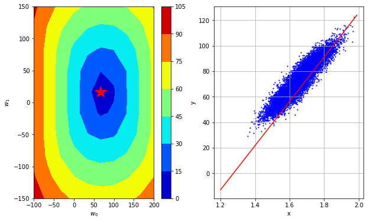

```python
# Generate the grid of parameters to be swept
grid_w0, grid_w1 = generate_w(num_intervals=10)

# Start the grid search
start_time = datetime.datetime.now()
grid_losses = grid_search(y, tx, grid_w0, grid_w1, kind='mae')

# Select the best combinaison
loss_star, w0_star, w1_star = get_best_parameters(grid_w0, grid_w1,
                                                  grid_losses)
end_time = datetime.datetime.now()
execution_time = (end_time - start_time).total_seconds()

# Print the results
print(
    "Grid Search: loss*={l}, w0*={w0}, w1*={w1}, execution time={t:.3f} seconds"
    .format(l=loss_star, w0=w0_star, w1=w1_star, t=execution_time))

# Plot the results
fig = grid_visualization(grid_losses, grid_w0, grid_w1, mean_x, std_x, height,
                         weight)
fig.set_size_inches(10.0, 6.0)
#fig.savefig("grid_plot")  # Optional saving
```

## Test with MAE and grid spacing 50

```
Grid Search: loss*=2.436828558945931, w0*=71.42857142857142, w1*=15.306122448979579, execution time=2.632 seconds
```

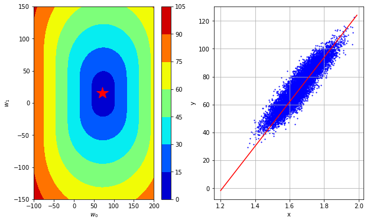

```python
# Generate the grid of parameters to be swept
grid_w0, grid_w1 = generate_w(num_intervals=50)

# Start the grid search
start_time = datetime.datetime.now()
grid_losses = grid_search(y, tx, grid_w0, grid_w1, kind='mae')

# Select the best combinaison
loss_star, w0_star, w1_star = get_best_parameters(grid_w0, grid_w1,
                                                  grid_losses)
end_time = datetime.datetime.now()
execution_time = (end_time - start_time).total_seconds()

# Print the results
print(
    "Grid Search: loss*={l}, w0*={w0}, w1*={w1}, execution time={t:.3f} seconds"
    .format(l=loss_star, w0=w0_star, w1=w1_star, t=execution_time))

# Plot the results
fig = grid_visualization(grid_losses, grid_w0, grid_w1, mean_x, std_x, height,
                         weight)
fig.set_size_inches(10.0, 6.0)
#fig.savefig("grid_plot")  # Optional saving
```

# 3 Gradient Descent

Again, please fill in the functions `compute_gradient` below:

The gradients are $$\nabla\mathcal{L}_{MSE} = -\frac{1}{N}\tilde{X}^T\vec{e}$$ $$\nabla\mathcal{L}_{MAE} = -\frac{1}{N}\sum_n^N\frac{\partial h(e_n)}{\partial e_n}\tilde{X}_{ni};\quad \frac{\partial h(a)}{\partial a} = \partial h(a) = sgn(a), a\neq 0$$

```python
def compute_gradient(y, tx, w, kind='mse'):
    """Compute the gradient."""
    error = y - tx.dot(w)
    if kind == 'mse':
        return -tx.T.dot(error)/len(y)
    elif kind == 'mae':
        return -np.sign(error).dot(tx)/len(y) #Sum rows
    else:
        raise NotImplementedError
print(compute_gradient(y, tx, [100,20]), '\n')
print(compute_gradient(y, tx, [50,10]), '\n')
```

```
[26.706078    6.52028757]

[-23.293922    -3.47971243]
```

Please fill in the functions `gradient_descent` below:

```python
def gradient_descent(y, tx, initial_w, max_iters, gamma, kind='mse'):
    """Gradient descent algorithm."""
    # Define parameters to store w and loss
    ws = [initial_w]
    losses = []
    w = initial_w.astype(float)
    for n_iter in range(max_iters):
        # compute gradient and loss
        gradient = compute_gradient(y, tx, w, kind=kind)
        loss = compute_loss(y, tx, w, kind=kind)
        # update w by gradient
        #gamma = 1./(n_iter + 1)
        w = w - gamma * gradient
        # store w and loss
        ws.append(w)
        losses.append(loss)
        print("Gradient Descent({bi}/{ti}): loss={l}, w0={w0}, w1={w1}".format(
            bi=n_iter, ti=max_iters - 1, l=loss, w0=w[0], w1=w[1]))

    return losses, ws
```

Test your gradient descent function through gradient descent demo shown below:

```python
# from gradient_descent import *
from plots import gradient_descent_visualization
np.random.seed(42)
# Define the parameters of the algorithm.
max_iters = 50
gamma = 0.7

# Initialization
w_initial = np.array([0, 0])

# Start gradient descent.
start_time = datetime.datetime.now()
gradient_losses, gradient_ws = gradient_descent(y, tx, w_initial, max_iters,
                                                gamma)
end_time = datetime.datetime.now()

# Print result
exection_time = (end_time - start_time).total_seconds()
print(
    "Gradient Descent: execution time={t:.3f} seconds".format(t=exection_time))
```

```
Gradient Descent(0/49): loss=2792.236712759167, w0=51.305745401473644, w1=9.435798704492269
Gradient Descent(1/49): loss=265.3024621089598, w0=66.69746902191571, w1=12.266538315840005
Gradient Descent(2/49): loss=37.87837955044126, w0=71.31498610804834, w1=13.115760199244333
Gradient Descent(3/49): loss=17.41021212017447, w0=72.70024123388814, w1=13.370526764265632
Gradient Descent(4/49): loss=15.568077051450457, w0=73.11581777164007, w1=13.446956733772023
Gradient Descent(5/49): loss=15.402284895265295, w0=73.24049073296565, w1=13.469885724623941
Gradient Descent(6/49): loss=15.387363601208632, w0=73.27789262136334, w1=13.476764421879516
Gradient Descent(7/49): loss=15.38602068474353, w0=73.28911318788263, w1=13.478828031056189
Gradient Descent(8/49): loss=15.38589982226167, w0=73.29247935783842, w1=13.47944711380919
Gradient Descent(9/49): loss=15.385888944638305, w0=73.29348920882515, w1=13.47963283863509
Gradient Descent(10/49): loss=15.3858879656522, w0=73.29379216412117, w1=13.479688556082861
Gradient Descent(11/49): loss=15.385887877543452, w0=73.29388305070998, w1=13.479705271317192
Gradient Descent(12/49): loss=15.385887869613665, w0=73.29391031668663, w1=13.479710285887492
Gradient Descent(13/49): loss=15.38588786889998, w0=73.29391849647962, w1=13.479711790258582
Gradient Descent(14/49): loss=15.385887868835754, w0=73.29392095041752, w1=13.479712241569908
Gradient Descent(15/49): loss=15.385887868829974, w0=73.29392168659889, w1=13.479712376963306
Gradient Descent(16/49): loss=15.385887868829453, w0=73.2939219074533, w1=13.479712417581325
Gradient Descent(17/49): loss=15.385887868829403, w0=73.29392197370962, w1=13.479712429766732
Gradient Descent(18/49): loss=15.3858878688294, w0=73.29392199358652, w1=13.479712433422353
Gradient Descent(19/49): loss=15.3858878688294, w0=73.2939219995496, w1=13.47971243451904
Gradient Descent(20/49): loss=15.3858878688294, w0=73.29392200133852, w1=13.479712434848047
Gradient Descent(21/49): loss=15.385887868829398, w0=73.29392200187519, w1=13.479712434946748
Gradient Descent(22/49): loss=15.3858878688294, w0=73.29392200203618, w1=13.479712434976358
Gradient Descent(23/49): loss=15.3858878688294, w0=73.29392200208449, w1=13.479712434985242
Gradient Descent(24/49): loss=15.385887868829398, w0=73.29392200209898, w1=13.479712434987906
Gradient Descent(25/49): loss=15.385887868829398, w0=73.29392200210333, w1=13.479712434988706
Gradient Descent(26/49): loss=15.3858878688294, w0=73.29392200210464, w1=13.479712434988945
Gradient Descent(27/49): loss=15.385887868829403, w0=73.29392200210502, w1=13.479712434989018
Gradient Descent(28/49): loss=15.3858878688294, w0=73.29392200210513, w1=13.47971243498904
Gradient Descent(29/49): loss=15.385887868829398, w0=73.29392200210518, w1=13.479712434989047
Gradient Descent(30/49): loss=15.3858878688294, w0=73.29392200210519, w1=13.479712434989048
Gradient Descent(31/49): loss=15.3858878688294, w0=73.29392200210519, w1=13.479712434989048
Gradient Descent(32/49): loss=15.3858878688294, w0=73.29392200210519, w1=13.479712434989048
Gradient Descent(33/49): loss=15.3858878688294, w0=73.29392200210519, w1=13.479712434989048
Gradient Descent(34/49): loss=15.3858878688294, w0=73.29392200210519, w1=13.479712434989048
Gradient Descent(35/49): loss=15.3858878688294, w0=73.29392200210519, w1=13.479712434989048
Gradient Descent(36/49): loss=15.3858878688294, w0=73.29392200210519, w1=13.479712434989048
Gradient Descent(37/49): loss=15.3858878688294, w0=73.29392200210519, w1=13.479712434989048
Gradient Descent(38/49): loss=15.3858878688294, w0=73.29392200210519, w1=13.479712434989048
Gradient Descent(39/49): loss=15.3858878688294, w0=73.29392200210519, w1=13.479712434989048
Gradient Descent(40/49): loss=15.3858878688294, w0=73.29392200210519, w1=13.479712434989048
Gradient Descent(41/49): loss=15.3858878688294, w0=73.29392200210519, w1=13.479712434989048
Gradient Descent(42/49): loss=15.3858878688294, w0=73.29392200210519, w1=13.479712434989048
Gradient Descent(43/49): loss=15.3858878688294, w0=73.29392200210519, w1=13.479712434989048
Gradient Descent(44/49): loss=15.3858878688294, w0=73.29392200210519, w1=13.479712434989048
Gradient Descent(45/49): loss=15.3858878688294, w0=73.29392200210519, w1=13.479712434989048
Gradient Descent(46/49): loss=15.3858878688294, w0=73.29392200210519, w1=13.479712434989048
Gradient Descent(47/49): loss=15.3858878688294, w0=73.29392200210519, w1=13.479712434989048
Gradient Descent(48/49): loss=15.3858878688294, w0=73.29392200210519, w1=13.479712434989048
Gradient Descent(49/49): loss=15.3858878688294, w0=73.29392200210519, w1=13.479712434989048
Gradient Descent: execution time=0.017 seconds
```

```python
# Time Visualization
from ipywidgets import IntSlider, interact


def plot_figure(n_iter):
    fig = gradient_descent_visualization(gradient_losses, gradient_ws,
                                         grid_losses, grid_w0, grid_w1, mean_x,
                                         std_x, height, weight, n_iter)
    fig.set_size_inches(10.0, 6.0)


interact(plot_figure, n_iter=IntSlider(min=1, max=len(gradient_ws)))
```

```
<function __main__.plot_figure(n_iter)>
```

# 4 Stochastic gradient descent

```python
def compute_stoch_gradient(y, tx, w, kind='mse'):
    """Compute a stochastic gradient from just few examples n and their
    corresponding y_n labels."""
    error = y - tx.dot(w)
    if kind == 'mse':
        return -tx.T.dot(error) / len(y)
    elif kind == 'mae':
        return -np.sign(error).dot(tx) / len(y)
    else:
        raise NotImplementedError


def stochastic_gradient_descent(y,
                                tx,
                                initial_w,
                                batch_size,
                                max_iters,
                                gamma,
                                kind='mse'):
    """Stochastic gradient descent algorithm."""
    # implement stochastic gradient descent
    # Define parameters to store w and loss
    ws = [initial_w]
    losses = []
    w = initial_w.astype(float)
    for n_iter in range(max_iters):
        for new_y, new_tx in batch_iter(y,
                                        tx,
                                        batch_size=batch_size,
                                        num_batches=1):
            # compute gradient and loss
            gradient = compute_stoch_gradient(new_y, new_tx, w, kind=kind)
            loss = compute_loss(new_y, new_tx, w, kind=kind)
            # update w by gradient
            #gamma = 1./(n_iter + 1)
            w = w - gamma * gradient
            # store w and loss
            ws.append(w)
            losses.append(loss)
        print("Gradient Descent({bi}/{ti}): loss={l}, w0={w0}, w1={w1}".format(
            bi=n_iter, ti=max_iters - 1, l=loss, w0=w[0], w1=w[1]))
    return losses, ws
```

##### My implementation without using helper function, for a single random data point.

```
def stochastic_gradient_descent(
        y, tx, initial_w, batch_size, max_iters, gamma, kind = 'mse'):
    """Stochastic gradient descent algorithm."""
    # implement stochastic gradient descent
    indices = np.arange(len(y))
    # Define parameters to store w and loss
    ws = [initial_w]
    losses = []
    w = initial_w.astype(float)
    for n_iter in range(max_iters):
        np.random.shuffle(indices)
        new_y = y[indices[:batch_size]]
        new_tx = tx[indices[:batch_size],:]
        # compute gradient and loss
        gradient = compute_stoch_gradient(new_y, new_tx, w, kind = kind)
        loss = compute_loss(new_y, new_tx, w, kind = kind)
        # update w by gradient
        #gamma = 1./(n_iter + 1)
        w = w - gamma * gradient
        # store w and loss
        ws.append(w)
        losses.append(loss)
        print("Gradient Descent({bi}/{ti}): loss={l}, w0={w0}, w1={w1}".format(
              bi=n_iter, ti=max_iters - 1, l=loss, w0=w[0], w1=w[1]))
    return losses, ws
```

## MSE

```python
# from stochastic_gradient_descent import *

# Define the parameters of the algorithm.
max_iters = 50
gamma = 0.7
batch_size = 1
np.random.seed(42)
# Initialization
w_initial = np.array([0, 0])

# Start SGD.
start_time = datetime.datetime.now()
sgd_losses, sgd_ws = stochastic_gradient_descent(y, tx, w_initial, batch_size,
                                                 max_iters, gamma)
end_time = datetime.datetime.now()

# Print result
exection_time = (end_time - start_time).total_seconds()
print("SGD: execution time={t:.3f} seconds".format(t=exection_time))
```

```
Gradient Descent(0/49): loss=3088.5539174094515, w0=55.01620524046767, w1=33.170896316855256
Gradient Descent(1/49): loss=17.248867469970246, w0=59.127639311515246, w1=34.501309749101296
Gradient Descent(2/49): loss=694.8651164484139, w0=85.22299932281697, w1=8.758457008146795
Gradient Descent(3/49): loss=52.89556415515684, w0=78.02316231965824, w1=-0.47244021391767
Gradient Descent(4/49): loss=522.9228068709054, w0=55.38548684858817, w1=35.032642954117925
Gradient Descent(5/49): loss=77.85628402405794, w0=46.6505479052654, w1=22.237379055545915
Gradient Descent(6/49): loss=510.7525330112771, w0=69.02324292287675, w1=22.62189700345778
Gradient Descent(7/49): loss=3.114912935154701, w0=67.27606958389414, w1=21.263199681475733
Gradient Descent(8/49): loss=29.40614238208817, w0=72.64431133836518, w1=19.419567496310233
Gradient Descent(9/49): loss=118.36454804180572, w0=83.4145136150622, w1=6.224953262950438
Gradient Descent(10/49): loss=69.62272151382706, w0=75.15435217090445, w1=16.138105410635468
Gradient Descent(11/49): loss=4.422368381130662, w0=73.07254502001173, w1=13.824545181498431
Gradient Descent(12/49): loss=0.786050755394806, w0=73.95022932560623, w1=12.722998157061967
Gradient Descent(13/49): loss=9.340686429913239, w0=70.92469256309367, w1=18.263979081871618
Gradient Descent(14/49): loss=1.8993181859019637, w0=72.28899891512167, w1=18.428051536776998
Gradient Descent(15/49): loss=3.3714180477877354, w0=74.10668692103246, w1=17.808594603803684
Gradient Descent(16/49): loss=5.190226891938605, w0=71.85137710770307, w1=19.229067792773524
Gradient Descent(17/49): loss=51.62147624691349, w0=78.96397485550065, w1=15.650878302867264
Gradient Descent(18/49): loss=65.06089780986325, w0=70.97900899122384, w1=6.211144353241584
Gradient Descent(19/49): loss=0.03573376366873509, w0=71.16614286949114, w1=6.2652071665030205
Gradient Descent(20/49): loss=4.340840400343618, w0=73.22867131592206, w1=5.942649959111085
Gradient Descent(21/49): loss=3.3203498110540406, w0=71.42480246957182, w1=6.762260518048343
Gradient Descent(22/49): loss=31.682556535193438, w0=76.99695693660605, w1=13.235567830453666
Gradient Descent(23/49): loss=3.1489417854893076, w0=75.24026602760142, w1=13.655314795597288
Gradient Descent(24/49): loss=6.970217525190066, w0=72.62668358683429, w1=18.062685134212007
Gradient Descent(25/49): loss=1.2183197234785699, w0=73.71936530124567, w1=17.593963688668612
Gradient Descent(26/49): loss=99.29987846996995, w0=63.85458548106872, w1=6.992011564674931
Gradient Descent(27/49): loss=287.13071819158756, w0=80.62921226761023, w1=30.252077985512592
Gradient Descent(28/49): loss=571.4313421206962, w0=56.96483576455648, w1=-7.039868285182102
Gradient Descent(29/49): loss=515.9963304484654, w0=79.45208557060204, w1=-0.4665120913243692
Gradient Descent(30/49): loss=430.61035584182696, w0=58.90949204580604, w1=24.623452701441366
Gradient Descent(31/49): loss=40.6369171069989, w0=65.22013216903117, w1=27.288147586608744
Gradient Descent(32/49): loss=169.37537243927778, w0=78.10375995744901, w1=15.659000614108185
Gradient Descent(33/49): loss=4.1415730517558265, w0=76.08912808270844, w1=16.425489194653316
Gradient Descent(34/49): loss=11.700169282356466, w0=79.4753008332794, w1=16.172361848286943
Gradient Descent(35/49): loss=18.351836363885955, w0=75.23445190451429, w1=16.45084452540497
Gradient Descent(36/49): loss=53.982657380324724, w0=67.96100676258064, w1=7.631923004524456
Gradient Descent(37/49): loss=22.285977299199207, w0=72.63436291776668, w1=10.896440922547
Gradient Descent(38/49): loss=8.175832323659074, w0=75.46496632997156, w1=13.695933123891146
Gradient Descent(39/49): loss=0.835748717876521, w0=74.55996149931097, w1=12.308193436306171
Gradient Descent(40/49): loss=50.21706710436013, w0=81.5751397409719, w1=7.3206944689649465
Gradient Descent(41/49): loss=40.07153129177429, w0=87.84172578649452, w1=12.224195905933081
Gradient Descent(42/49): loss=29.489279438644935, w0=82.46590084050976, w1=11.133475592174362
Gradient Descent(43/49): loss=122.26582883006343, w0=71.51964521342603, w1=9.030079167157695
Gradient Descent(44/49): loss=20.340698518207436, w0=67.05490730982595, w1=15.434993333270711
Gradient Descent(45/49): loss=62.24194046618687, w0=74.86497143612243, w1=19.623383508033477
Gradient Descent(46/49): loss=0.003908535699360782, w0=74.80308149360046, w1=19.608681029408785
Gradient Descent(47/49): loss=63.0230333499197, w0=66.94416473090845, w1=13.034492609957237
Gradient Descent(48/49): loss=31.242168340797804, w0=72.47745714808485, w1=7.93443298790838
Gradient Descent(49/49): loss=25.68261841541466, w0=67.4605889968269, w1=11.361471954932808
SGD: execution time=0.036 seconds
```

```python
# Time Visualization
from ipywidgets import IntSlider, interact


def plot_figure(n_iter):
    fig = gradient_descent_visualization(sgd_losses, sgd_ws, grid_losses,
                                         grid_w0, grid_w1, mean_x, std_x,
                                         height, weight, n_iter)
    fig.set_size_inches(10.0, 6.0)
interact(plot_figure, n_iter=IntSlider(min=1, max=len(sgd_ws)))
```

```
<function __main__.plot_figure(n_iter)>
```

## MAE

```python
# from stochastic_gradient_descent import *

# Define the parameters of the algorithm.
max_iters = 50
gamma = 3
batch_size = 1
np.random.seed(42)
# Initialization
w_initial = np.array([0, 0])

# Start SGD.
start_time = datetime.datetime.now()
sgd_losses, sgd_ws = stochastic_gradient_descent(y,
                                                 tx,
                                                 w_initial,
                                                 batch_size,
                                                 max_iters,
                                                 gamma,
                                                 kind='mae')
end_time = datetime.datetime.now()

# Print result
exection_time = (end_time - start_time).total_seconds()
print("SGD: execution time={t:.3f} seconds".format(t=exection_time))
```

```
Gradient Descent(0/49): loss=39.29728945747691, w0=3.0, w1=1.8087886744571091
Gradient Descent(1/49): loss=34.01905239963366, w0=6.0, w1=2.7795546475379234
Gradient Descent(2/49): loss=29.556740479535506, w0=9.0, w1=-0.1799200709337252
Gradient Descent(3/49): loss=38.6986970054678, w0=12.0, w1=3.6663741790672106
Gradient Descent(4/49): loss=20.087485195845026, w0=15.0, w1=-1.0388460914604987
Gradient Descent(5/49): loss=40.37293164349393, w0=18.0, w1=3.355665644086226
Gradient Descent(6/49): loss=30.468029739122237, w0=21.0, w1=3.4072264347208603
Gradient Descent(7/49): loss=30.234828641315698, w0=24.0, w1=5.740190128134186
Gradient Descent(8/49): loss=22.806935140119634, w0=27.0, w1=4.709890672844196
Gradient Descent(9/49): loss=21.50471783489511, w0=30.0, w1=1.034579691385185
Gradient Descent(10/49): loss=17.6926162315325, w0=33.0, w1=-2.5657683943158722
Gradient Descent(11/49): loss=29.983193825003514, w0=36.0, w1=0.7682006932794057
Gradient Descent(12/49): loss=10.969937850264, w0=39.0, w1=-2.9969812203597685
Gradient Descent(13/49): loss=0.9191983520427698, w0=42.0, w1=-8.491194009440015
Gradient Descent(14/49): loss=17.045648917459516, w0=45.0, w1=-8.130411869868151
Gradient Descent(15/49): loss=10.417367248592168, w0=48.0, w1=-9.152793484797032
Gradient Descent(16/49): loss=2.951794153035898, w0=51.0, w1=-11.042298661302526
Gradient Descent(17/49): loss=7.891690440675603, w0=54.0, w1=-12.551531834659299
Gradient Descent(18/49): loss=23.448721317384205, w0=57.0, w1=-9.004966660777761
Gradient Descent(19/49): loss=9.321132113049394, w0=60.0, w1=-8.138269292636647
Gradient Descent(20/49): loss=5.930031841415879, w0=63.0, w1=-8.607436941621224
Gradient Descent(21/49): loss=0.5203501732888967, w0=66.0, w1=-9.970524774634535
Gradient Descent(22/49): loss=16.411953306119855, w0=69.0, w1=-6.485351839801632
Gradient Descent(23/49): loss=0.38762279184707893, w0=72.0, w1=-7.202177371815328
Gradient Descent(24/49): loss=17.833050338235253, w0=69.0, w1=-2.1431783482516202
Gradient Descent(25/49): loss=1.7399682989302505, w0=66.0, w1=-0.8562854515514386
Gradient Descent(26/49): loss=6.727908258997111, w0=69.0, w1=2.367897647490147
Gradient Descent(27/49): loss=12.615118043696128, w0=72.0, w1=6.527763625462219
Gradient Descent(28/49): loss=6.104680286913727, w0=75.0, w1=11.255369222746694
Gradient Descent(29/49): loss=4.370754718273396, w0=78.0, w1=12.13231365800047
Gradient Descent(30/49): loss=6.253368148174449, w0=75.0, w1=15.796402824124623
Gradient Descent(31/49): loss=1.6740240353786717, w0=72.0, w1=14.5296399443842
Gradient Descent(32/49): loss=0.054552464880334384, w0=75.0, w1=11.821750405005789
Gradient Descent(33/49): loss=0.6171045509069799, w0=72.0, w1=12.963132992299311
Gradient Descent(34/49): loss=4.333847710506632, w0=75.0, w1=12.73887330591117
Gradient Descent(35/49): loss=0.9042603703515937, w0=72.0, w1=12.93587349275757
Gradient Descent(36/49): loss=1.4471724021324377, w0=69.0, w1=9.298427406842912
Gradient Descent(37/49): loss=2.2365564063161187, w0=72.0, w1=11.394042084786877
Gradient Descent(38/49): loss=2.09297502938243, w0=75.0, w1=14.36106903311183
Gradient Descent(39/49): loss=0.9239104988816251, w0=72.0, w1=9.760851529613975
Gradient Descent(40/49): loss=5.385295456767942, w0=75.0, w1=7.6279767277784165
Gradient Descent(41/49): loss=7.643481080692943, w0=78.0, w1=9.975427828591886
Gradient Descent(42/49): loss=1.3091182232298024, w0=81.0, w1=10.584108537907051
Gradient Descent(43/49): loss=7.033021317307053, w0=78.0, w1=10.007638419720058
Gradient Descent(44/49): loss=5.72809441106147, w0=75.0, w1=14.311304819229306
Gradient Descent(45/49): loss=1.9073773725124212, w0=78.0, w1=15.920148270588609
Gradient Descent(46/49): loss=1.1718539779706276, w0=75.0, w1=15.20747292986724
Gradient Descent(47/49): loss=3.8711086628350273, w0=72.0, w1=12.697894847556713
Gradient Descent(48/49): loss=1.2693122831954753, w0=75.0, w1=9.932781834795652
Gradient Descent(49/49): loss=4.162209375292665, w0=72.0, w1=11.982091601586184
SGD: execution time=0.035 seconds
```

```python
# Time Visualization
from ipywidgets import IntSlider, interact


def plot_figure(n_iter):
    fig = gradient_descent_visualization(sgd_losses, sgd_ws, grid_losses,
                                         grid_w0, grid_w1, mean_x, std_x,
                                         height, weight, n_iter)
    fig.set_size_inches(10.0, 6.0)


interact(plot_figure, n_iter=IntSlider(min=1, max=len(gradient_ws)))
```

```
<function __main__.plot_figure(n_iter)>
```

# 5 Effect of Outliers and MAE Cost Function, and Subgradient Descent

### Exercise 5

Load and plot data containing outliers

```python
height, weight, gender = load_data(sub_sample=False, add_outlier=True)
x, mean_x, std_x = standardize(height)
y, tx = build_model_data(x, weight)
```

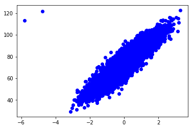

```python
plt.plot(x,y, 'ob')
```

## MSE SGD

```python
# from stochastic_gradient_descent import *

# Define the parameters of the algorithm.
max_iters = 50
gamma = 0.7
batch_size = 1
np.random.seed(42)
# Initialization
w_initial = np.array([0, 0])

# Start SGD.
start_time = datetime.datetime.now()
sgd_losses, sgd_ws = stochastic_gradient_descent(y, tx, w_initial, batch_size,
                                                 max_iters, gamma)
end_time = datetime.datetime.now()

# Print result
exection_time = (end_time - start_time).total_seconds()
print("SGD: execution time={t:.3f} seconds".format(t=exection_time))
```

```
Gradient Descent(0/49): loss=2333.302011572707, w0=47.81878262086199, w1=-16.513356297480435
Gradient Descent(1/49): loss=500.39589918851266, w0=69.96348811009219, w1=-12.810388298966185
Gradient Descent(2/49): loss=1084.5931694704914, w0=37.361320910946034, w1=54.90257348981656
Gradient Descent(3/49): loss=96.1878026523609, w0=47.07028824013783, w1=61.94857622296958
Gradient Descent(4/49): loss=4485.983065830487, w0=113.37461241672436, w1=-36.5033284185556
Gradient Descent(5/49): loss=585.3050505642827, w0=137.3245382945428, w1=-1.4906341782709447
Gradient Descent(6/49): loss=1927.0072260065047, w0=93.86804187011421, w1=11.787831990616464
Gradient Descent(7/49): loss=178.6642624195981, w0=80.63584714772571, w1=1.5117481893485785
Gradient Descent(8/49): loss=3.982191368138134, w0=78.66036048850086, w1=-0.9277051399073013
Gradient Descent(9/49): loss=3.5309234554444697, w0=80.52054999130308, w1=-0.06448715359546409
Gradient Descent(10/49): loss=36.17799605572175, w0=74.56618720972794, w1=1.7259283523162956
Gradient Descent(11/49): loss=183.64746796598206, w0=61.15072901380104, w1=16.48288885899459
Gradient Descent(12/49): loss=283.64843412274354, w0=77.82332525554722, w1=12.483332746113954
Gradient Descent(13/49): loss=19.087733694547115, w0=73.49828432849738, w1=5.015931812919856
Gradient Descent(14/49): loss=13.683643915564021, w0=77.16024705868084, w1=6.289910578005491
Gradient Descent(15/49): loss=2.0760362700328026, w0=75.7338826085377, w1=5.38685620513804
Gradient Descent(16/49): loss=31.781693107888206, w0=81.3147480652326, w1=11.70659822976858
Gradient Descent(17/49): loss=4.7907432163491, w0=79.14796973046411, w1=11.607014817921852
Gradient Descent(18/49): loss=0.4284666209747424, w0=79.7959645518595, w1=12.793630502016198
Gradient Descent(19/49): loss=41.56565068710588, w0=73.41361877045877, w1=4.437543677556565
Gradient Descent(20/49): loss=2.35022569067489, w0=74.93125547825856, w1=3.8818079048104046
Gradient Descent(21/49): loss=274.56794895376237, w0=58.52770129098906, w1=47.26962565798182
Gradient Descent(22/49): loss=205.67077733845136, w0=44.33061138524843, w1=31.499886110522688
Gradient Descent(23/49): loss=455.82683535115444, w0=65.4661335847147, w1=26.974415195913497
Gradient Descent(24/49): loss=469.44206039594457, w0=86.91498481707737, w1=-8.417747854657318
Gradient Descent(25/49): loss=451.6901551961263, w0=65.87558482344153, w1=9.103591740833522
Gradient Descent(26/49): loss=31.213674843702766, w0=71.40635342706514, w1=1.6348097025124
Gradient Descent(27/49): loss=30.404453547762206, w0=65.9477487997994, w1=6.905525846506877
Gradient Descent(28/49): loss=133.22460082931278, w0=77.37403904697615, w1=26.76684820969332
Gradient Descent(29/49): loss=0.04523699549669063, w0=77.1634867836619, w1=26.943591097638773
Gradient Descent(30/49): loss=207.2969203180586, w0=62.910382493308255, w1=10.545311261016149
Gradient Descent(31/49): loss=53.4231822402886, w0=70.1460385517098, w1=13.985707419084491
Gradient Descent(32/49): loss=0.08423189003291774, w0=69.85872817557927, w1=13.446091198391173
Gradient Descent(33/49): loss=21.651627732740213, w0=74.46509281356501, w1=15.979503464661905
Gradient Descent(34/49): loss=14.72643705520788, w0=70.66615765827429, w1=20.64954792194571
Gradient Descent(35/49): loss=42.3860308110081, w0=64.2211355330378, w1=18.0898414689656
Gradient Descent(36/49): loss=35.70077181565502, w0=70.13609592000083, w1=11.989944937597539
Gradient Descent(37/49): loss=57.062349647903574, w0=62.658054555114866, w1=14.193117161417943
Gradient Descent(38/49): loss=31.456569724976895, w0=68.21030079699548, w1=9.098218499303147
Gradient Descent(39/49): loss=0.25199451955939206, w0=68.70724609495916, w1=8.514589259792446
Gradient Descent(40/49): loss=86.48578704002719, w0=77.91355215652514, w1=1.996795009451545
Gradient Descent(41/49): loss=140.81534024809264, w0=89.66085114153148, w1=11.176288261996273
Gradient Descent(42/49): loss=43.16968826482797, w0=83.15652223690716, w1=9.853321224035458
Gradient Descent(43/49): loss=158.785809258125, w0=70.68214477456611, w1=24.559303909057135
Gradient Descent(44/49): loss=130.2634881165961, w0=59.383551129591346, w1=7.731794178848119
Gradient Descent(45/49): loss=12.870230520232623, w0=62.93500518530261, w1=2.89442029674672
Gradient Descent(46/49): loss=272.8684963835324, w0=79.28771524987178, w1=19.58146108537776
Gradient Descent(47/49): loss=56.24294639457491, w0=71.86355957621545, w1=13.341653096528589
Gradient Descent(48/49): loss=31.372818251563917, w0=77.40840960904164, w1=9.263606300338429
Gradient Descent(49/49): loss=84.81708253184689, w0=68.29135192132188, w1=9.126097517682949
SGD: execution time=0.035 seconds
```

```python
# Time Visualization
from ipywidgets import IntSlider, interact


def plot_figure(n_iter):
    fig = gradient_descent_visualization(sgd_losses, sgd_ws, grid_losses,
                                         grid_w0, grid_w1, mean_x, std_x,
                                         height, weight, n_iter)
    fig.set_size_inches(10.0, 6.0)


interact(plot_figure, n_iter=IntSlider(min=1, max=len(gradient_ws)))
```

```
<function __main__.plot_figure(n_iter)>
```

## MSE FGD

```python
# from gradient_descent import *
from plots import gradient_descent_visualization
np.random.seed(42)
# Define the parameters of the algorithm.
max_iters = 50
gamma = 0.7

# Initialization
w_initial = np.array([0, 0])

# Start gradient descent.
start_time = datetime.datetime.now()
gradient_losses, gradient_ws = gradient_descent(y, tx, w_initial, max_iters,
                                                gamma)
end_time = datetime.datetime.now()

# Print result
exection_time = (end_time - start_time).total_seconds()
print(
    "Gradient Descent: execution time={t:.3f} seconds".format(t=exection_time))
```

```
Gradient Descent(0/49): loss=2793.063324919039, w0=51.311949971831694, w1=9.375829281932628
Gradient Descent(1/49): loss=266.5853963287441, w0=66.70553496338118, w1=12.1885780665124
Gradient Descent(2/49): loss=39.202382755617954, w0=71.32361046084603, w1=13.03240270188633
Gradient Descent(3/49): loss=18.73791153403659, w0=72.70903311008549, w1=13.28555009249851
Gradient Descent(4/49): loss=16.89610912409425, w0=73.12465990485732, w1=13.361494309682165
Gradient Descent(5/49): loss=16.73034690719944, w0=73.24934794328888, w1=13.384277574837261
Gradient Descent(6/49): loss=16.715428307678906, w0=73.28675435481834, w1=13.39111255438379
Gradient Descent(7/49): loss=16.714085633722057, w0=73.29797627827718, w1=13.393163048247748
Gradient Descent(8/49): loss=16.713964793065944, w0=73.30134285531483, w1=13.393778196406936
Gradient Descent(9/49): loss=16.71395391740689, w0=73.30235282842612, w1=13.393962740854693
Gradient Descent(10/49): loss=16.71395293859758, w0=73.30265582035952, w1=13.39401810418902
Gradient Descent(11/49): loss=16.71395285050474, w0=73.30274671793954, w1=13.394034713189317
Gradient Descent(12/49): loss=16.713952842576386, w0=73.30277398721354, w1=13.394039695889408
Gradient Descent(13/49): loss=16.71395284186283, w0=73.30278216799574, w1=13.394041190699435
Gradient Descent(14/49): loss=16.713952841798612, w0=73.3027846222304, w1=13.394041639142442
Gradient Descent(15/49): loss=16.713952841792835, w0=73.3027853585008, w1=13.394041773675344
Gradient Descent(16/49): loss=16.713952841792313, w0=73.30278557938192, w1=13.394041814035216
Gradient Descent(17/49): loss=16.713952841792267, w0=73.30278564564625, w1=13.394041826143177
Gradient Descent(18/49): loss=16.71395284179226, w0=73.30278566552556, w1=13.394041829775565
Gradient Descent(19/49): loss=16.71395284179226, w0=73.30278567148935, w1=13.394041830865282
Gradient Descent(20/49): loss=16.71395284179226, w0=73.30278567327848, w1=13.394041831192196
Gradient Descent(21/49): loss=16.71395284179226, w0=73.30278567381522, w1=13.39404183129027
Gradient Descent(22/49): loss=16.71395284179226, w0=73.30278567397625, w1=13.394041831319692
Gradient Descent(23/49): loss=16.71395284179226, w0=73.30278567402455, w1=13.394041831328519
Gradient Descent(24/49): loss=16.71395284179226, w0=73.30278567403904, w1=13.394041831331167
Gradient Descent(25/49): loss=16.71395284179226, w0=73.30278567404339, w1=13.394041831331963
Gradient Descent(26/49): loss=16.71395284179226, w0=73.3027856740447, w1=13.394041831332201
Gradient Descent(27/49): loss=16.71395284179226, w0=73.30278567404508, w1=13.394041831332272
Gradient Descent(28/49): loss=16.71395284179226, w0=73.30278567404521, w1=13.394041831332293
Gradient Descent(29/49): loss=16.71395284179226, w0=73.30278567404524, w1=13.3940418313323
Gradient Descent(30/49): loss=16.71395284179226, w0=73.30278567404525, w1=13.394041831332302
Gradient Descent(31/49): loss=16.71395284179226, w0=73.30278567404525, w1=13.394041831332302
Gradient Descent(32/49): loss=16.71395284179226, w0=73.30278567404525, w1=13.394041831332302
Gradient Descent(33/49): loss=16.71395284179226, w0=73.30278567404525, w1=13.394041831332302
Gradient Descent(34/49): loss=16.71395284179226, w0=73.30278567404525, w1=13.394041831332302
Gradient Descent(35/49): loss=16.71395284179226, w0=73.30278567404525, w1=13.394041831332302
Gradient Descent(36/49): loss=16.71395284179226, w0=73.30278567404525, w1=13.394041831332302
Gradient Descent(37/49): loss=16.71395284179226, w0=73.30278567404525, w1=13.394041831332302
Gradient Descent(38/49): loss=16.71395284179226, w0=73.30278567404525, w1=13.394041831332302
Gradient Descent(39/49): loss=16.71395284179226, w0=73.30278567404525, w1=13.394041831332302
Gradient Descent(40/49): loss=16.71395284179226, w0=73.30278567404525, w1=13.394041831332302
Gradient Descent(41/49): loss=16.71395284179226, w0=73.30278567404525, w1=13.394041831332302
Gradient Descent(42/49): loss=16.71395284179226, w0=73.30278567404525, w1=13.394041831332302
Gradient Descent(43/49): loss=16.71395284179226, w0=73.30278567404525, w1=13.394041831332302
Gradient Descent(44/49): loss=16.71395284179226, w0=73.30278567404525, w1=13.394041831332302
Gradient Descent(45/49): loss=16.71395284179226, w0=73.30278567404525, w1=13.394041831332302
Gradient Descent(46/49): loss=16.71395284179226, w0=73.30278567404525, w1=13.394041831332302
Gradient Descent(47/49): loss=16.71395284179226, w0=73.30278567404525, w1=13.394041831332302
Gradient Descent(48/49): loss=16.71395284179226, w0=73.30278567404525, w1=13.394041831332302
Gradient Descent(49/49): loss=16.71395284179226, w0=73.30278567404525, w1=13.394041831332302
Gradient Descent: execution time=0.021 seconds
```

```python
# Time Visualization
from ipywidgets import IntSlider, interact

def plot_figure(n_iter):
    fig = gradient_descent_visualization(
        gradient_losses, gradient_ws, grid_losses, grid_w0, grid_w1, mean_x, std_x, height, weight, n_iter)
    fig.set_size_inches(10.0, 6.0)

interact(plot_figure, n_iter=IntSlider(min=1, max=len(gradient_ws)))
```

```
<function __main__.plot_figure(n_iter)>
```

### Exercise 6

Modify the function `compute_loss(y, tx, w)` for the Mean Absolute Error cost function here

```python
#Save This notebook
! jupyter nbconvert --to html_ch ex02_DONE.ipynb
```

```
[NbConvertApp] Converting notebook ex02_DONE.ipynb to html_ch
[NbConvertApp] Writing 1192120 bytes to ex02_DONE.html
```